# Notes on Statistics

## Logistic Regression

Binary outcome $logit(p) = X \beta$ (no projection error). Deviance changes are $\chi^2$ distributed (d.f. = change in number of parameters)

```r
cars$fastcar <- as.factor(ifelse(cars$dist > mean(cars$dist), 1, 0))
cars$fastcar
```

```
##  [1] 0 0 0 0 0 0 0 0 0 0 0 0 0 0 0 0 0 0 1 0 0 1 1 0 0 1 0 0 0 0 1 0 1 1 1
## [36] 0 1 1 0 1 1 1 1 1 1 1 1 1 1 1
## Levels: 0 1
```

```r
fit <- glm(fastcar~speed,family=binomial("logit"), data=cars)
exp(cbind(coef(fit), confint(fit))) # odds scale
```

```
##                                 2.5 %     97.5 %
## (Intercept) 0.0002753734 1.379764e-06 0.01114898
## speed       1.6302311986 1.305802e+00 2.23493096
```

```r
summary(fit)
```

```
##
## Call:
## glm(formula = fastcar ~ speed, family = binomial("logit"), data = cars)
##
## Deviance Residuals:
##     Min       1Q   Median       3Q      Max
## -1.8787  -0.5420  -0.1474   0.6129   1.9954
##
## Coefficients:
##             Estimate Std. Error z value Pr(>|z|)
## (Intercept)  -8.1974     2.2447  -3.652 0.000260 ***
## speed         0.4887     0.1343   3.640 0.000273 ***
## ---
## Signif. codes:  0 '***' 0.001 '**' 0.01 '*' 0.05 '.' 0.1 ' ' 1
##
## (Dispersion parameter for binomial family taken to be 1)
##
##     Null deviance: 68.029  on 49  degrees of freedom
## Residual deviance: 37.785  on 48  degrees of freedom
## AIC: 41.785
##
## Number of Fisher Scoring iterations: 6
```

```r
anova(fit, test="Chisq")
```

```
## Analysis of Deviance Table
##
## Model: binomial, link: logit
##
## Response: fastcar
##
## Terms added sequentially (first to last)
##
##
##       Df Deviance Resid. Df Resid. Dev  Pr(>Chi)
## NULL                     49     68.029
## speed  1   30.244        48     37.785 3.809e-08 ***
## ---
## Signif. codes:  0 '***' 0.001 '**' 0.01 '*' 0.05 '.' 0.1 ' ' 1
```

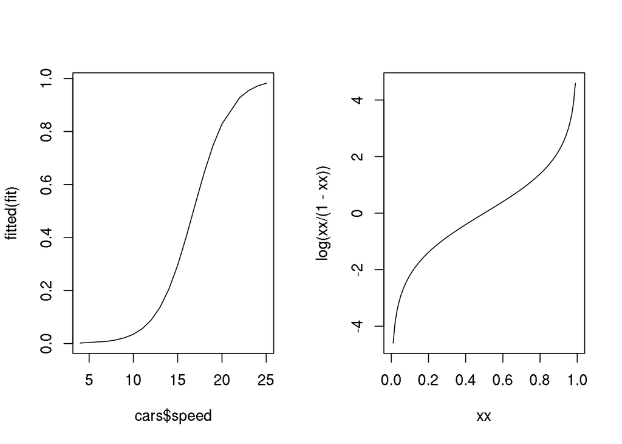

```r
op <- par(mfrow = c(1, 2))
plot(cars$speed, fitted(fit), type="l")
xx <- seq(0, 1, 0.01)
plot(xx, log(xx/ (1 - xx)), type="l")
```

```r
par(op)

(p <- predict(fit, newdata = list(speed=c(10,20)), type = "response"))
```

```
##          1          2
## 0.03522414 0.82878694
```

```r
ifelse(p > 0.5, "Fast", "Slow")
```

```
##      1      2
## "Slow" "Fast"
```

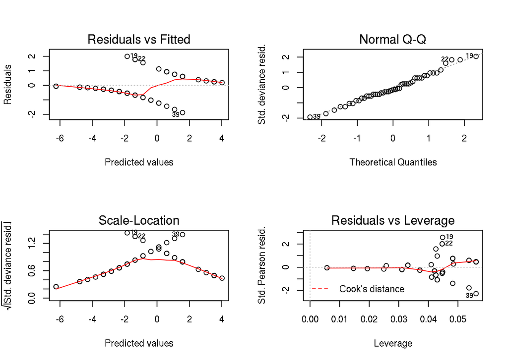

```r
op <- par(mfrow = c(2, 2))
plot(fit)
```

```r
par(op)
```

Overdispersion

```r
c(fit$deviance, fit$df.residual, summary(fit)$dispersion)
```

```
## [1] 37.78469 48.00000  1.00000
```

```r
(fi <- deviance(fit) / df.residual(fit)) # overdispersion if too > 1
```

```
## [1] 0.7871811
```

```r
# if fi >> 1
qfit <- glm(fastcar~speed,family=quasibinomial("logit"), data=cars)

c(qfit$deviance,
  qfit$df.residual,
  summary(qfit)$dispersion,
  summary(fit)$dispersion * fit$df.residual,
  summary(qfit)$dispersion * qfit$df.residual,
  deviance(fit),
  deviance(qfit)
  )
```

```
## [1] 37.7846946 48.0000000  0.7604123 48.0000000 36.4997882 37.7846946
## [7] 37.7846946
```

```r
pchisq(summary(qfit)$dispersion * fit$df.residual, fit$df.residual, lower = F) # p-value < 0.05 for overdispersion
```

```
## [1] 0.8875642
```

```r
anova(fit, qfit, test="Chisq")
```

```
## Analysis of Deviance Table
##
## Model 1: fastcar ~ speed
## Model 2: fastcar ~ speed
##   Resid. Df Resid. Dev Df Deviance Pr(>Chi)
## 1        48     37.785
## 2        48     37.785  0        0
```

## Robust Regression

```r
fitLse <- lm(dist ~ speed, data=cars)
```

1. Least Absolute Values (LAV), uses median (higher estimation variance that LSE)

```r
suppressMessages(suppressWarnings(library(quantreg)))
fitLav <- rq(dist ~ speed, data=cars)
summary(fitLav)
```

```
##
## Call: rq(formula = dist ~ speed, data = cars)
##
## tau: [1] 0.5
##
## Coefficients:
##             coefficients lower bd  upper bd
## (Intercept) -11.60000    -26.21128  -0.10897
## speed         3.40000      2.72000   4.50041
```

2. M-Estimation: 2a) Huber (combines: lse around center, lav in sides), 2b) Bisquare weights (MM) (resistant to extreme observations in tails)

```r
library(MASS)
fitHuber <- rlm(dist ~ speed, data=cars)
fitBisquare <- rlm(dist ~ speed, data=cars, method="MM") # or robustbase::lmrob
summary(fitHuber)
```

```
##
## Call: rlm(formula = dist ~ speed, data = cars)
## Residuals:
##      Min       1Q   Median       3Q      Max
## -26.9411  -8.5603  -0.6208  10.3733  45.9652
##
## Coefficients:
##             Value    Std. Error t value
## (Intercept) -16.5275   6.3308    -2.6107
## speed         3.7734   0.3892     9.6949
##
## Residual standard error: 13.29 on 48 degrees of freedom
```

```r
summary(fitBisquare)
```

```
##
## Call: rlm(formula = dist ~ speed, data = cars, method = "MM")
## Residuals:
##     Min      1Q  Median      3Q     Max
## -25.803  -8.055  -0.142  10.355  47.534
##
## Coefficients:
##             Value    Std. Error t value
## (Intercept) -15.5136   6.2359    -2.4878
## speed         3.6658   0.3834     9.5616
##
## Residual standard error: 12.57 on 48 degrees of freedom
```

3. Least Trimmed Squares (LTS), uses ordered 50% lower LSE, robust, needs more data

```r
suppressMessages(suppressWarnings(library(robustbase)))
fitLts <- ltsReg(dist ~ speed, data=cars)
summary(fitLts)
```

```
##
## Call:
## ltsReg.formula(formula = dist ~ speed, data = cars)
##
## Residuals (from reweighted LS):
##     Min      1Q  Median      3Q     Max
## -24.176  -7.117   0.000   6.522  26.923
##
## Coefficients:
##           Estimate Std. Error t value Pr(>|t|)
## Intercept -14.8162     5.3137  -2.788  0.00774 **
## speed       3.5496     0.3307  10.733 5.42e-14 ***
## ---
## Signif. codes:  0 '***' 0.001 '**' 0.01 '*' 0.05 '.' 0.1 ' ' 1
##
## Residual standard error: 11.86 on 45 degrees of freedom
## Multiple R-Squared: 0.7191,  Adjusted R-squared: 0.7128
## F-statistic: 115.2 on 1 and 45 DF,  p-value: 5.42e-14
```

4. Least Median Squares (LMS)

```r
#library(MASS)
fitLms <- lqs(dist ~ speed, data=cars)
coef(fitLms)
```

```
## (Intercept)       speed
##  -12.692308    3.166667
```

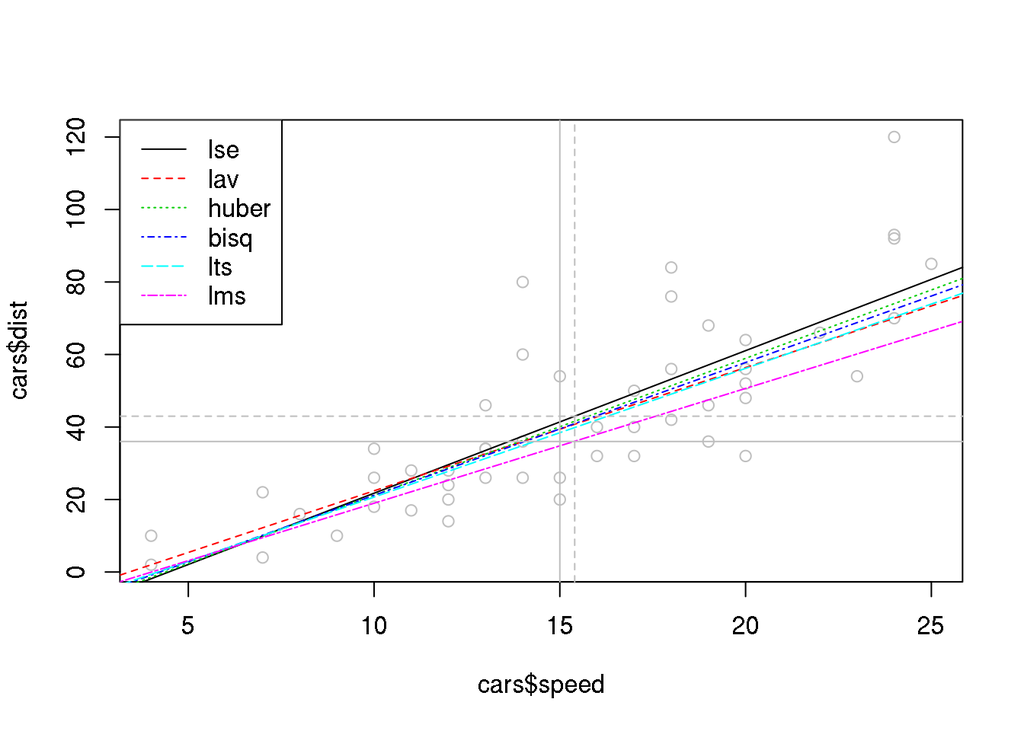

```r
models <- list(lse=fitLse, lav=fitLav, huber=fitHuber, bisq=fitBisquare, lts=fitLts, lms=fitLms)
cmodels <- matrix(0, length(models), 2)
rownames(cmodels) <- names(models)
colnames(cmodels) <- c("intercept", "speed")
plot(cars$speed, cars$dist, col="gray")
for(i in 1:length(models)) {
  cc <- coef(models[[i]])
  cmodels[i, 1] <- cc[1]
  cmodels[i, 2] <- cc[2]
  abline(coef=cc, col=i, lty=i)
}
abline(h=c(median(cars$dist), mean(cars$dist)),
       v=c(median(cars$speed), mean(cars$speed)),
       lty=c(1,2), col=8)
legend("topleft", legend=names(models),
       col=c(1:length(models), 8,8), lty=c(1:length(models), 8,8))
```

```r
cmodels
```

```
##       intercept    speed
## lse   -17.57909 3.932409
## lav   -11.60000 3.400000
## huber -16.52753 3.773429
## bisq  -15.51357 3.665817
## lts   -14.81618 3.549632
## lms   -12.69231 3.166667
```

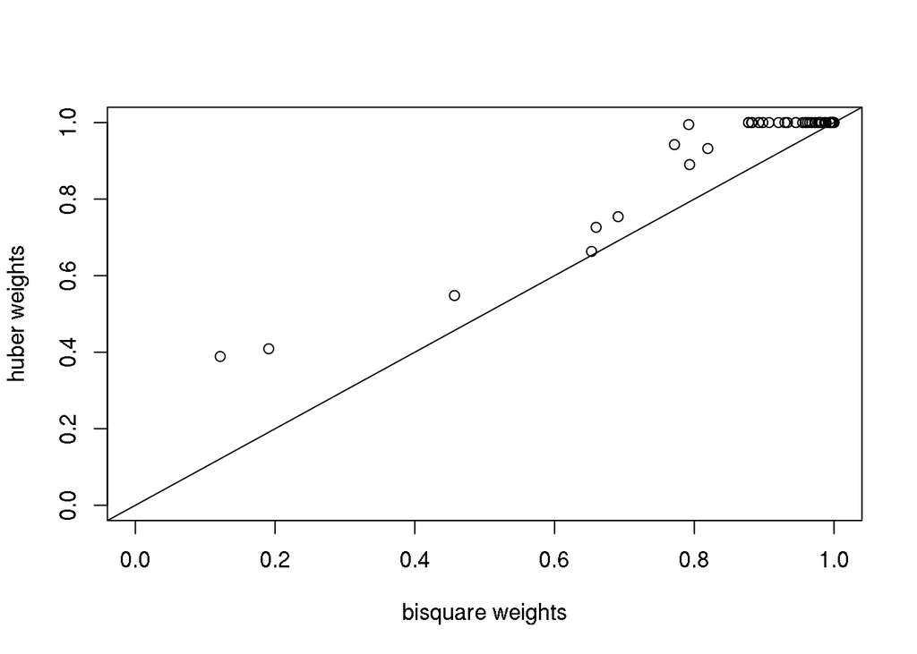

```r
# weights (huber gives more 1, lse is all 1)
plot(fitBisquare$w, fitHuber$w, xlab="bisquare weights", ylab="huber weights", xlim=c(0,1), ylim=c(0,1))
abline(0,1)
```

```r
for(i in 1:length(models)) {
  cc <- coef(models[[i]])
   print(cc)
}
```

```
## (Intercept)       speed
##  -17.579095    3.932409
## (Intercept)       speed
##       -11.6         3.4
## (Intercept)       speed
##  -16.527535    3.773429
## (Intercept)       speed
##  -15.513570    3.665817
##  Intercept      speed
## -14.816176   3.549632
## (Intercept)       speed
##  -12.692308    3.166667
```

## Hierachical Models

Base average (population)

$\theta \approx N(\mu, \tau^2)$

Sample given base

$Y|\theta \approx N(\theta, \sigma^2)$

$E(\theta | Y) = B\mu + (1 - B) Y$

Shrink sample towards population average

$B = \frac{ \sigma^2}{ \sigma^2 + \tau^2 }$

**EOF**